# Session 4

Tim Riffe

8/22/2019

# An Excel example

We use `here()` for file path construction relawtive to our project location. Which makes everything portable. And `readxl` will do the heavy lifting right now, followed by some `dplyr` wrangling.

```r
library(here)
library(tidyverse)
library(readxl)
```

Let’s take a first stab at reading this in:

```r
EURO <- read_xlsx(here("data","eurostat.xlsx"),
          sheet = "Sheet 1",
          skip = 6,
          range = "A8:X63",
          na = ":") %>%
  # now tidy it up with dplyr
  select(c("TIME",as.character(2007:2018))) %>%
  # remove first row
  slice(-1) %>%
  # GEO is the new one, TIME is the old name
  rename(GEO = TIME) %>%
  # this is the main tidying step:
  # year should be a variable rather than a header,
  # and gather stacks
  gather(key = "Year",
         value = "Deaths",
         -GEO) %>%
  mutate(Year = as.integer(Year))
```

Now the object `EURO` is something plottable in `ggplot2`, or at least it’s a general sort of object with no hidden quirks.

# A more involved Excel example

That was rather satisfying wasn’t it? How about something a little trickier?

## Download two spreadsheets

Download from these two links and put the files straight in the `data` folder. (direct downloads):

(Yes, there are ways to do this programmatically from `R`)

## read in TFR dataset

```r
path <- here("data", "WPP2019_FERT_F04_TOTAL_FERTILITY.xlsx")
TFR <- read_xlsx(path,
          sheet = "ESTIMATES",
          skip = 16,
          col_types = c(
            rep("text", 7),
            rep("numeric",14)),
          na = "…") %>%
  gather(key = "Year",
         value = "TFR",
         8:21) %>%
  mutate(Year = substr(Year, 1, 4)) %>%
  rename("ISO" = "Country code") %>%
  filter(Year == "1990")
```

## read in family planning dataset

```r
path <- here("data",
"Table_Model-based_estimates_Countries_2019.xlsx")
FP <- read_xlsx(path,
          sheet = "FP Indicators",
          skip = 4,
          col_types = c(
            rep("text",6),
            "numeric","numeric","text"
          ),
          na = "..") %>%
  rename("MarStat" = "Marital status",
         "ISO" = "ISO code",
         "Med_UI" = "Median estimate and uncertainty intervals") %>%
  filter(Indicator == "CPmod",
         Med_UI == "Median",
         MarStat == "AW",
         Year == "1990")
```

## Join the datasets

Now we have two joinable datasets as `data.frame`s, so let’s see how to do that using `dplyr`.

```r
FP_TFR <- left_join(FP,
                    TFR,
                    by = "ISO")
```

## Join SDG codes

```r
# get ISO-SDG lookup
ISOSDG <- read_xlsx(here("data","WPP2019_F01_LOCATIONS.xlsx"),
          sheet = "Sheet2",
          col_types = c("text","text"))

FP_TFR <- left_join(FP_TFR,
                    ISOSDG,
                    by = "ISO")
```

## Get SDG colors and labels

Now we make some helper objects for constructing the desired plot

```r
Colors <- c("#DEA0FD","#FF7F0E","#2ED9FF",
"#3283FE","#FFEE33","#AAF400",
"#1CBE4F","#B33E52")

names(Colors) <- c(947,1833,921,1832,1830,927,1835,1829)

labs <- c("Sub-Saharan Africa",
"Northern Africa and Western Asia",
"Central and Southern Asia",
"Eastern and South-Eastern Asia",
"Latin America and the Caribbean",
"Australia/New Zealand",
"Oceania*",
"Europe and Northern America")
names(labs) <- c(947,1833,921,1832,1830,927,1835,1829)
```

## Make the plot

Now for the plot:

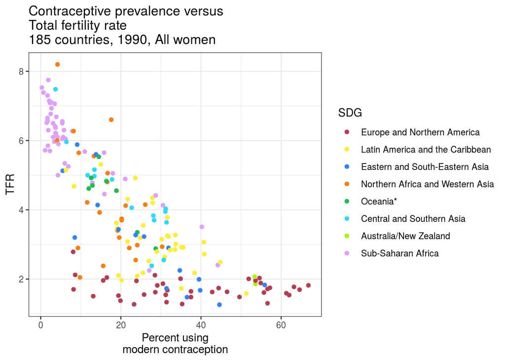

```r
FP_TFR %>%
  ggplot(mapping = aes(x = Percentage,
                       y = TFR,
                       color = SDG)) +
  geom_point() +
  scale_color_manual(labels = labs,
                     values  = Colors) +
labs(x="Percent using\nmodern contraception",
 title ="Contraceptive prevalence versus\nTotal fertility rate\n185 countries, 1990, All women"
) +
  theme_bw()
```